# Project 2: Data Mining, Classification, Prediction

SDS322E

# Mining, Classification, Prediction

## John Matthew Mason, jmm22836

### Introduction

This dataset was acquired from the [UCI Machine Learning Repository](https://archive.ics.uci.edu/ml/datasets/banknote+authentication#). They describe the data set as “data extracted from images that were taken for the evaluation of an authentication procedure for banknotes.”

```r
library(tidyverse)

banknote = read_csv("data_banknote_authentication.csv", col_names = c("variance",
    "skewness", "curtosis", "entropy", "class"))

banknote %>%
    glimpse()
```

```
## Rows: 1,372
## Columns: 5
## $ variance <dbl> 3.62160, 4.54590, 3.86600, 3.45660, 0.32924, 4.36840, 3.59120…
## $ skewness <dbl> 8.6661, 8.1674, -2.6383, 9.5228, -4.4552, 9.6718, 3.0129, -6.…
## $ curtosis <dbl> -2.80730, -2.45860, 1.92420, -4.01120, 4.57180, -3.96060, 0.7…
## $ entropy  <dbl> -0.44699, -1.46210, 0.10645, -3.59440, -0.98880, -3.16250, 0.…
## $ class    <dbl> 0, 0, 0, 0, 0, 0, 0, 0, 0, 0, 0, 0, 0, 0, 0, 0, 0, 0, 0, 0, 0…
```

The dataset contains 1,372 observations of 5 variables.

| Variable Name | Description |
| --- | --- |
| variance | variance of Wavelet Transformed image (continuous) |
| skewness | skewness of Wavelet Transformed image (continuous) |
| curtosis | curtosis of Wavelet Transformed image (continuous) |
| entropy | entropy of image (continuous) |
| class | 0 for authentic, 1 for inauthentic |

```r
banknote %>%
    group_by(class) %>%
    summarize(n())
```

```
## # A tibble: 2 × 2
##   class `n()`
##   <dbl> <int>
## 1     0   762
## 2     1   610
```

There are 762 observations in the authentic (0) class and 610 observations in the inauthentic (1) class.

### Cluster Analysis

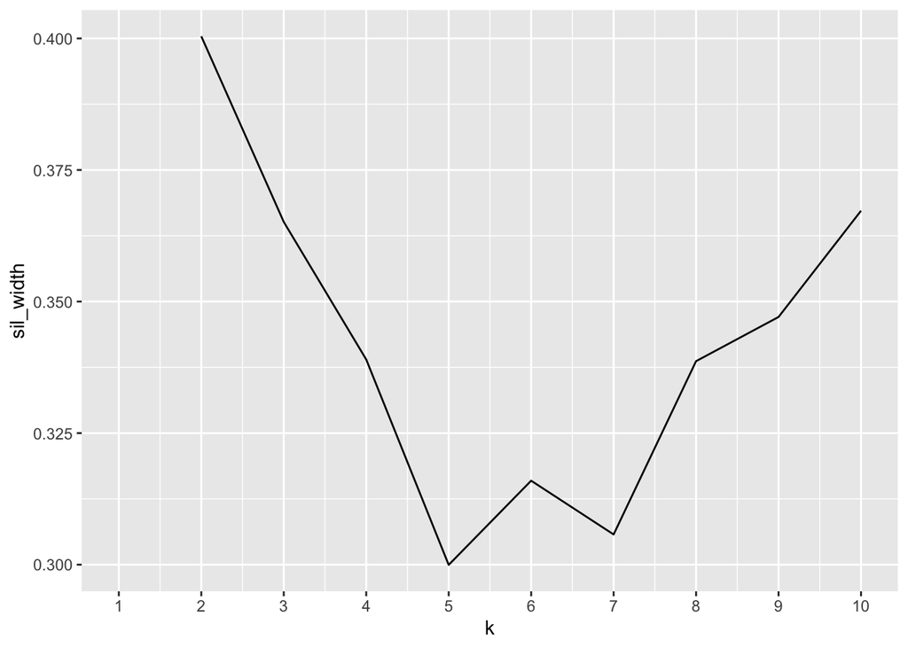

```r
library(cluster)

pam_dat <- banknote %>%
    select(variance, skewness, curtosis, entropy)
sil_width <- vector()

for (i in 2:10) {
    pam_fit <- pam(pam_dat, k = i)
    sil_width[i] <- pam_fit$silinfo$avg.width
}

ggplot() + geom_line(aes(x = 1:10, y = sil_width)) + scale_x_continuous(name = "k",
    breaks = 1:10)
```

We can see that the highest silhouette width occurs at `k=2`.

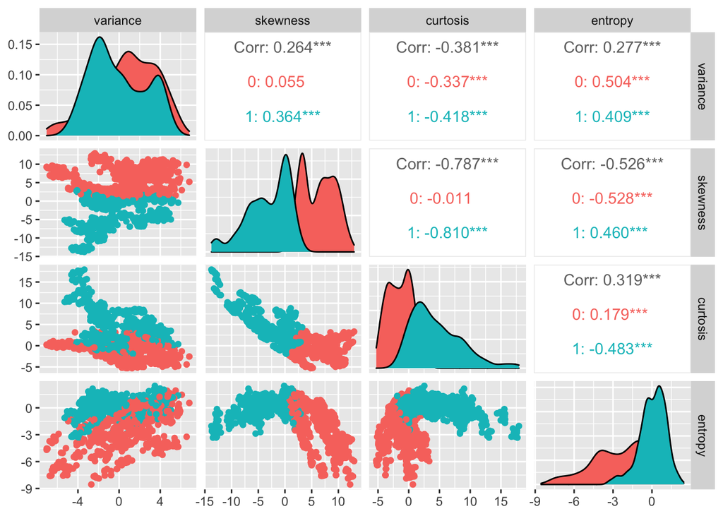

```r
library(GGally)

pam <- pam(pam_dat, k = 2)
pam_clust <- banknote %>%
    mutate(cluster = as.factor(pam$clustering - 1))

ggpairs(pam_clust, columns = 1:4, aes(color = cluster))
```

These plots show well defined boundaries between the cluster assignments, however the silhouette width suggests that the fit is not good.

```r
tab <- table(actual = pam_clust$class, predicted = pam_clust$cluster)
tab
```

```
##       predicted
## actual   0   1
##      0 487 275
##      1 244 366
```

```r
acc = sum(diag(tab))/sum(tab)
acc
```

```
## [1] 0.6217201
```

```r
sens = tab[1, 1]/rowSums(tab)[1]
sens  # true positive rate
```

```
##         0
## 0.6391076
```

```r
spec = tab[2, 2]/rowSums(tab)[2]
spec  # true negative rate
```

```
##   1
## 0.6
```

```r
ppv = tab[1, 1]/colSums(tab)[1]
ppv
```

```
##         0
## 0.6662107
```

```r
fpr = 1 - spec
fpr
```

```
##   1
## 0.4
```

```r
fnr = 1 - sens
fnr
```

```
##         0
## 0.3608924
```

Based on these metrics, it is clear that the PAM classifier does not do a good job of distinguishing between authentic and inauthentic checks.

The PAM classifier has a high false positive rate of `.4` and a high false negative rate of `.36`. For FPR and FNR, lower numbers are better.

The PPV (the proportion of cases predicted positive that are actually positive) is low at `.67`. For PPV, higher numbers are better.

### Dimensionality Reduction with PCA

```r
pca_dat <- banknote %>%
    select(variance, skewness, curtosis, entropy)

pca <- princomp(pca_dat, cor = T)
summary(pca, loadings = T)
```

```
## Importance of components:
##                          Comp.1    Comp.2     Comp.3     Comp.4
## Standard deviation     1.476450 1.1371697 0.59277520 0.41899713
## Proportion of Variance 0.544976 0.3232887 0.08784561 0.04388965
## Cumulative Proportion  0.544976 0.8682647 0.95611035 1.00000000
##
## Loadings:
##          Comp.1 Comp.2 Comp.3 Comp.4
## variance  0.249  0.755  0.603
## skewness  0.639        -0.116 -0.758
## curtosis -0.613 -0.153  0.510 -0.584
## entropy  -0.392  0.636 -0.602 -0.281
```

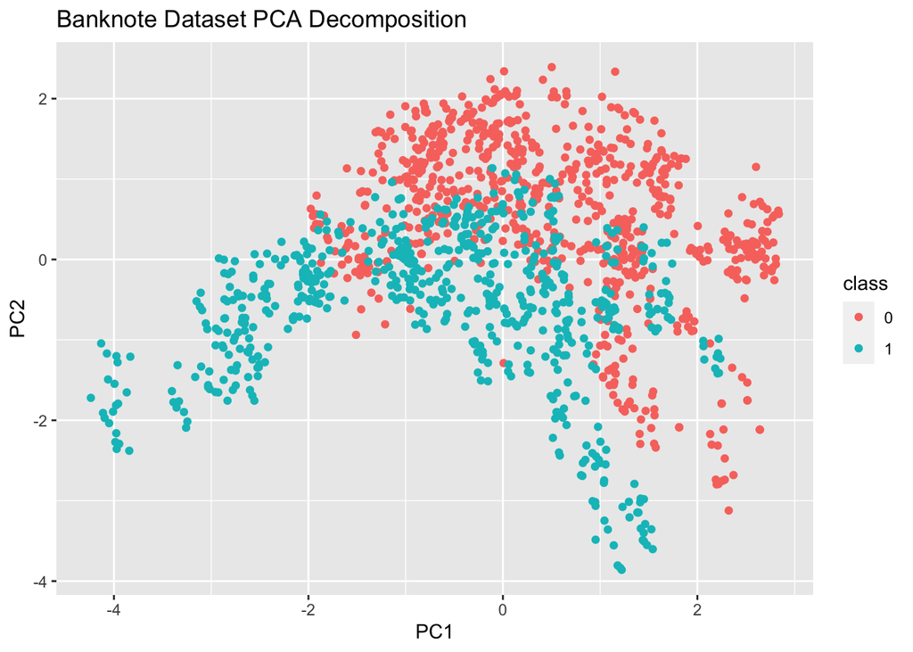

```r
pca_res <- data.frame(PC1 = pca$scores[, 1], PC2 = pca$scores[,
    2], class = as.factor(banknote$class))
ggplot(pca_res, aes(PC1, PC2)) + geom_point(aes(color = class)) +
    ggtitle("Banknote Dataset PCA Decomposition")
```

The first two principle components account for a majority (`.87`) of the variance in the data set. PC 1 increases with high variance and skewness and decreases with high curtosis and entropy. PC 2 increases with high variance and entropy but decreases slightly with curtosis.

In the plot, we can see some separation between the authentic (`class=0`) and inauthentic (`class=1`) checks. However, there is still significant overlap.

### Linear Classifier

```r
log_fit <- glm(class ~ variance + skewness + curtosis + entropy,
    data = banknote, family = "binomial")
score <- predict(log_fit, type = "response")

class_diag(score, banknote$class, positive = 1)
```

```
##           acc   sens   spec    ppv    f1     ba    auc
## Metrics 0.992 0.9902 0.9934 0.9918 0.991 0.9918 0.9998
```

```r
pred <- factor(score > 0.5, levels = c("TRUE", "FALSE"))
truth <- factor(banknote$class == 1, levels = c("TRUE", "FALSE"))
table(truth, pred)
```

```
##        pred
## truth   TRUE FALSE
##   TRUE   604     6
##   FALSE    5   757
```

The logistic regression classifier performs very well on in-sample data. The AUC of `.9998` is exceptional.

```r
library(caret)

cv <- trainControl(method = "cv", number = 5, classProbs = T,
    savePredictions = T)
fit <- train(class ~ variance + skewness + curtosis + entropy,
    data = banknote, trControl = cv, method = "glm")
class_diag(fit$pred$pred, fit$pred$obs, positive = 1)
```

```
##            acc sens  spec    ppv     f1    ba    auc
## Metrics 0.9767    1 0.958 0.9502 0.9744 0.979 0.9996
```

The model also performs very well when tested using cross validation. We do not see a significant decrease in AUC, which means that our model is not overfitting the data.

### Non-Parametric Classifier

```r
library(caret)

knn_fit <- knn3(class ~ variance + skewness + curtosis + entropy,
    data = banknote, k = 45)
y_hat_knn <- predict(knn_fit, banknote)

class_diag(y_hat_knn[, 1], banknote$class, positive = 0)
```

```
##            acc   sens spec ppv     f1     ba    auc
## Metrics 0.9927 0.9869    1   1 0.9934 0.9934 0.9998
```

The KNN classifier performs very well on in-sample data. The AUC of `.9998` is exceptional.

```r
cv <- trainControl(method = "cv", number = 5, classProbs = T,
    savePredictions = T)
fit <- train(class ~ variance + skewness + curtosis + entropy,
    data = banknote, trControl = cv, method = "knn", tuneGrid = expand.grid(k = 45))
class_diag(fit$pred$pred, fit$pred$obs, positive = 1)
```

```
##            acc sens   spec   ppv     f1     ba    auc
## Metrics 0.9891    1 0.9803 0.976 0.9879 0.9902 0.9994
```

The model also performs very well when tested using cross validation. We do not see a significant decrease in AUC, which means that our model is not overfitting the data.

### Regression/Numeric Prediction

```r
fit <- lm(variance ~ ., data = banknote)
y_hat <- predict(fit)

mean((banknote$variance - y_hat)^2)
```

```
## [1] 1.251963
```

The linear regression model gives a MSE of `1.25`. The variance of the true variable is `8.08`, so a MSE of `1.25` is OK but not great.

```r
k = 5  #choose number of folds

data <- banknote[sample(nrow(banknote)), ]  #randomly order rows
folds <- cut(seq(1:nrow(banknote)), breaks = k, labels = F)  #create folds

diags <- NULL
for (i in 1:k) {
    train <- data[folds != i, ]
    test <- data[folds == i, ]
    ## Fit linear regression model to training set
    fit <- lm(variance ~ ., data = train)
    ## Get predictions/y-hats on test set (fold i)
    yhat <- predict(fit, newdata = test)
    ## Compute prediction error (MSE) for fold i
    diags <- mean((test$variance - yhat)^2)
}
mean(diags)
```

```
## [1] 1.371439
```

MSE increases somewhat when tested using cross validation, so the model shows some signs of overfitting.

### Python

```r
library(reticulate)
```

```python
banknote_variance_mean = r.banknote['variance'].mean()
```

In Python, use the Pandas library to calculate the mean of the column `variance`.

```r
py$banknote_variance_mean
```

```
## [1] 0.4337353
```

We can access the Python variable `banknote_variance_mean` in R.